# W241 Final Project - Tweets are the new folktales

Arriaga, Hue, Khural, Moran

August 3, 2021

## 0.1 Libraries

```r
library(data.table)
library(foreign)
library(tidyverse)
library(dplyr)
library(readr)

# Calculate power
library(effsize)
library(pwr)

# Correlation checks
library(ggpubr)
library(corrplot)
library(PerformanceAnalytics)

# Variance
library(sandwich)

# Reports
library(stargazer)
```

Let’s load the data.

```r
df<-data.table::fread("../data/processed/tweets_data.csv")
df$truth_f <- factor(df$truth, levels=c("FALSE","TRUE"))
df$sentiment_f <- factor(df$sentiment, levels = c("positive","negative"))

# Robust standard error
rse <- function(model) {
  sqrt(diag(vcovHC(model)))
  }
```

## 0.2 Experiment Design

Our main goal is to evaluate if truthfulness is a variable that has a short term impact in memory. We can perform an hypotesis testing comparing all positive tweets to all negative tweers.

Based on the literature, we expect that tweets with fake information are less likely to be remembered. In regards to sentiment, Xie and Zhang (2017) found that negative emotions enchance the visual long-term memory. For the power analysis estimation, we will consider the base group to be the treatment with true and negative emotion content. This will be compared with the treatment with the lowest sample size.

```r
# Base group: TN
table1<- table(df$truth_f,df$sentiment_f)
table1
```

```
##
##         positive negative
##   FALSE       26       26
##   TRUE        29       30
```

```r
# We adjusted the levels based on the literature
# Confirmation check

# This line outputs "False" "true", meaning fake=0, fact=1
levels(df$truth_f)
```

```
## [1] "FALSE" "TRUE"
```

```r
# Now for sentiment: positive=0, negative=1
levels(df$sentiment_f)
```

```
## [1] "positive" "negative"
```

# 1 Attrition

We encountered attrition in the treatments TP (10%) and TN (3%). We followed Gerber and Green (2012) extreme bounds to gauge the potential consequences of attrition.

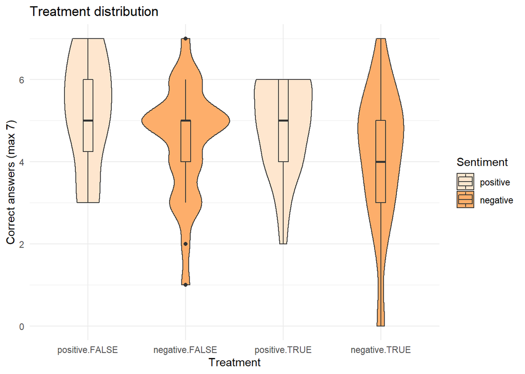

```r
p <- ggplot(df[attrition!=1], aes(x=interaction(sentiment_f,truth_f),
                                  y=total_correct,
                                  fill=sentiment_f)) +
  geom_violin()+
  labs(title="Treatment distribution",x="Treatment", y = "Correct answers (max 7)")+
  geom_boxplot(width=0.1) +
  guides(fill=guide_legend(title = "Sentiment"))+
  scale_fill_brewer(palette = "Oranges")+
  theme_minimal()
p
```

We believe that filling attrition metrics with lower bound will reduce the effect size between treatments.

```r
df[(attrition==1 & truth_f=="TRUE" & sentiment_f=="positive")]$total_correct <-df[(attrition==0 & truth_f=="TRUE" & sentiment_f=="positive")]$total_correct %>% max()

df[(attrition==1 & truth_f=="TRUE" & sentiment_f=="negative")]$total_correct <-
df[(attrition==0 & truth_f=="TRUE" & sentiment_f=="negative")]$total_correct %>% min()

# Check that lower bounds were added
df[(attrition==1 & truth_f=="TRUE" & sentiment_f=="positive")]$total_correct
```

```
## [1] 6 6 6
```

```r
df[(attrition==1 & truth_f=="TRUE" & sentiment_f=="negative")]$total_correct
```

```
## [1] 0
```

## 1.1 Power analysis

```r
# Let's see the least optimistic one: smaller effect
# The level values are consistent with our literatue (base=Fake-Positive)
tp<- subset(df, truth_f=="TRUE" & sentiment_f=="positive")
tn<- subset(df, truth_f=="TRUE" & sentiment_f=="negative")
fp<- subset(df, truth_f=="FALSE" & sentiment_f=="positive")
fn<- subset(df, truth_f=="FALSE" & sentiment_f=="negative")

# Let's compare the coehn's do to see which one has the smaller effect size
# coehnd_tn_tp <- cohen.d(tn$total_correct,tp$total_correct)
# coehnd_tn_tp
# coehnd_tn_fp <- cohen.d(tn$total_correct,fp$total_correct)
# coehnd_tn_fp
# coehnd_tn_fn <- cohen.d(tn$total_correct,fn$total_correct)
# coehnd_tn_fn

# Baseline Fake-Positive with n=26
coehnd_fp_tn <- cohen.d(fp$total_correct,tn$total_correct)
coehnd_fp_tn
```

```
##
## Cohen's d
##
## d estimate: 0.7862568 (medium)
## 95 percent confidence interval:
##     lower     upper
## 0.2287903 1.3437232
```

```r
coehnd_fp_fn <- cohen.d(fp$total_correct,fn$total_correct)
coehnd_fp_fn
```

```
##
## Cohen's d
##
## d estimate: 0.5413391 (medium)
## 95 percent confidence interval:
##       lower       upper
## -0.02584629  1.10852450
```

```r
coehnd_fp_tp <- cohen.d(fp$total_correct,tp$total_correct)
coehnd_fp_tp
```

```
##
## Cohen's d
##
## d estimate: 0.2164672 (small)
## 95 percent confidence interval:
##      lower      upper
## -0.3268282  0.7597626
```

```r
# We can perform a power test given the effect sizes, samples
# Option one = check by smallest effect size
pwr.t2n.test(n1 = length(fp$truth) , n2= length(tp$truth), d = coehnd_fp_tp$estimate, sig.level = .95)
```

```
##
##      t test power calculation
##
##              n1 = 26
##              n2 = 29
##               d = 0.2164672
##       sig.level = 0.95
##           power = 0.9637201
##     alternative = two.sided
```

```r
# Option two = check by smallest sample size, then effect size
pwr.t2n.test(n1 = length(fp$truth) , n2= length(fn$truth), d = coehnd_fp_fn$estimate, sig.level = .95)
```

```
##
##      t test power calculation
##
##              n1 = 26
##              n2 = 26
##               d = 0.5413391
##       sig.level = 0.95
##           power = 0.9925383
##     alternative = two.sided
```

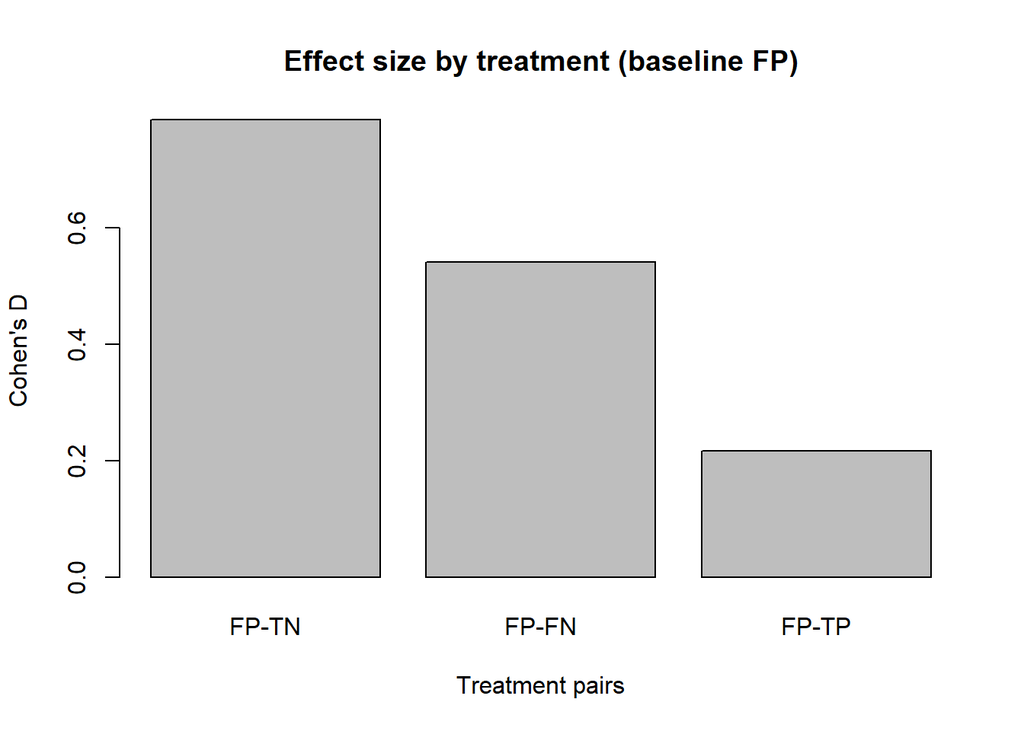

```r
# Plot power comparison by treatment
cohens <- data.frame(
  treatment = c("FP-TN","FP-FN","FP-TP"),
  cohen = c(coehnd_fp_tn$estimate, coehnd_fp_fn$estimate, coehnd_fp_tp$estimate)
)

sizes <- data.frame(
  treatment = c("FP","FN","TP","TN"),
  sample_size = as.numeric(table1)
)

barplot(cohens$cohen,
        main = "Effect size by treatment (baseline FP)",
        xlab = "Treatment pairs",
        ylab = "Cohen's D",
        names.arg = cohens$treatment)
```

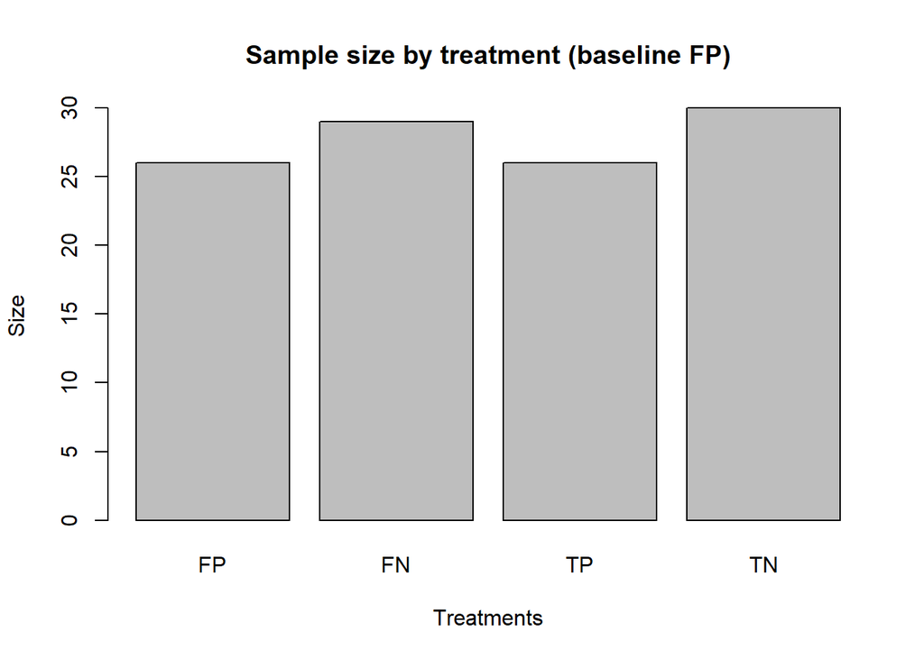

```r
barplot(sizes$sample_size,
        main = "Sample size by treatment (baseline FP)",
        xlab = "Treatments",
        ylab = "Size",
        names.arg = sizes$treatment)
```

# 2 Regression analysis

We performed a regression analysis to evaluate the short-memory retention based on the four treatments. Three models were proposed to analyze the data: reduced model which compared only the potential outcome (total correct responses) to the covariate of interest tweet truthfulness. A second model, includes the sentiment as a second independent variable and finaly, a third model adds the interaction between both covariates.

y: Total correct responses T: Truthfulness in the tweet S: Sentiment in the tweet

## 2.1 Model 1: Reduced model

$$y = \beta_0 + \beta_1T + \epsilon_1 \qquad (1)$$

## 2.2 Model 2: Extended model

$$y = \beta_0 + \beta_1T + \beta_2S + \epsilon_2 \qquad (2)$$

## 2.3 Model 3: Full model

$$y = \beta_0 + \beta_1T + \beta_2S + \beta_3T\cdot S + \epsilon_3 \qquad (3)$$

## 2.4 Correlation check

Before running the analysis we confirmed that our variables are not correlated. We performed a pearson’s correlation to evaluate if the covariates Fake and Positive were indepedent.

```r
# Let's check if our correlations are linear

cor(as.integer(df$truth_f),as.integer(df$sentiment_f), method = 'pearson')
```

```
## [1] 0.008458051
```

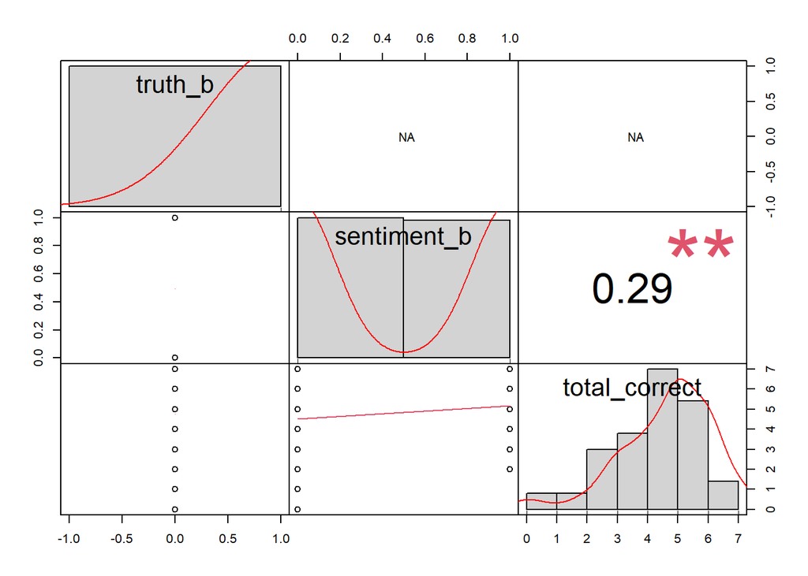

```r
# There seems to be almost no correlation between the variables.

# Let's plot a correlation matrix
df[, truth_b:= ifelse(truth_f=='fake', yes=1,no=0)]
df[, sentiment_b:= ifelse(sentiment_f=='positive', yes=1,no=0)]

df %>% select(c(truth_b,sentiment_b,total_correct)) %>% chart.Correlation()
```

Now we compute the three proposed models.

```r
model_1 <- df[, lm(total_correct~truth_f)]
summary(model_1, vcov=vcovHC(model_1))
```

```
##
## Call:
## lm(formula = total_correct ~ truth_f)
##
## Residuals:
##     Min      1Q  Median      3Q     Max
## -4.4576 -0.8654  0.1346  1.1346  2.5424
##
## Coefficients:
##             Estimate Std. Error t value Pr(>|t|)
## (Intercept)   4.8654     0.2069  23.512   <2e-16 ***
## truth_fTRUE  -0.4078     0.2838  -1.437    0.154
## ---
## Signif. codes:  0 '***' 0.001 '**' 0.01 '*' 0.05 '.' 0.1 ' ' 1
##
## Residual standard error: 1.492 on 109 degrees of freedom
## Multiple R-squared:  0.01858,    Adjusted R-squared:  0.009579
## F-statistic: 2.064 on 1 and 109 DF,  p-value: 0.1537
```

Looking at the linear regression, we didn’t find a correlation between fake tweets and memory retention. We fail to reject the null hypothesis in our reduced model.

```r
model_2 <- df[, lm(total_correct~truth_f+sentiment_f)]
summary(model_2, vcov=vcovHC(model_2))
```

```
##
## Call:
## lm(formula = total_correct ~ truth_f + sentiment_f)
##
## Residuals:
##     Min      1Q  Median      3Q     Max
## -4.0284 -0.9016  0.0984  0.9716  2.9716
##
## Coefficients:
##                     Estimate Std. Error t value Pr(>|t|)
## (Intercept)           5.3020     0.2407  22.028  < 2e-16 ***
## truth_fTRUE          -0.4004     0.2724  -1.470  0.14459
## sentiment_fnegative  -0.8732     0.2719  -3.212  0.00174 **
## ---
## Signif. codes:  0 '***' 0.001 '**' 0.01 '*' 0.05 '.' 0.1 ' ' 1
##
## Residual standard error: 1.432 on 108 degrees of freedom
## Multiple R-squared:  0.1041, Adjusted R-squared:  0.08755
## F-statistic: 6.277 on 2 and 108 DF,  p-value: 0.002636
```

```r
model_3 <- df[, lm(total_correct~truth_f+sentiment_f + truth_f:sentiment_f)]
summary(model_3, vcov=vcovHC(model_3))
```

```
##
## Call:
## lm(formula = total_correct ~ truth_f + sentiment_f + truth_f:sentiment_f)
##
## Residuals:
##     Min      1Q  Median      3Q     Max
## -3.9667 -0.9655  0.0345  1.0333  3.0333
##
## Coefficients:
##                                 Estimate Std. Error t value Pr(>|t|)
## (Intercept)                       5.2308     0.2819  18.557   <2e-16 ***
## truth_fTRUE                      -0.2653     0.3882  -0.683   0.4959
## sentiment_fnegative              -0.7308     0.3986  -1.833   0.0696 .
## truth_fTRUE:sentiment_fnegative  -0.2681     0.5468  -0.490   0.6250
## ---
## Signif. codes:  0 '***' 0.001 '**' 0.01 '*' 0.05 '.' 0.1 ' ' 1
##
## Residual standard error: 1.437 on 107 degrees of freedom
## Multiple R-squared:  0.1061, Adjusted R-squared:  0.08109
## F-statistic: 4.235 on 3 and 107 DF,  p-value: 0.007173
```

After running the full model, we found none of the covariates had a significant result.

Let’s organize the results in an organized comparison.

```r
# stargazer of all models
stargazer(model_1, model_2, model_3,
  # type="text",
  se = list(rse(model_1),rse(model_2), rse(model_3)),
column.labels = c("F","F+P","F+P+F*P"),
dep.var.labels   = "Correct responses",
covariate.labels = c("Fake information", "Positive sentiment", "Fake:Positive"),
# add.lines = list(c("optimized model", "Yes", "Yes","Yes")),
header=FALSE, type='text',
title = "Regression results"
)
```

# 3 Regression results

```
                                       Dependent variable:
                -----------------------------------------------------------------
                                        Correct responses
                         F                   F+P                  F+P+F*P
                        (1)                  (2)                    (3)
```

| Fake information -0.408 -0.400 -0.265 (0.284) (0.274) (0.341) |
| --- |
| Positive sentiment -0.873*** -0.731* (0.274) (0.382) |
| Fake:Positive -0.268 (0.551) |
| Constant 4.865*** 5.302*** 5.231*** (0.194) (0.232) (0.267) |

Observations 111 111 111  
R2 0.019 0.104 0.106  
Adjusted R2 0.010 0.088 0.081  
Residual Std. Error 1.492 (df = 109) 1.432 (df = 108) 1.437 (df = 107)  
F Statistic 2.064 (df = 1; 109) 6.277*** (df = 2; 108) 4.235*** (df = 3; 107) ===================================================================================== Note: *p<0.1; **p<0.05;*** p<0.01

We found that while fake information doesn’t seem to correlate with short-term memory retention, the positive sentiment of tweets does have a significant positive impact in the short-memory retention when explosed to tweets. This is an interesting finding because it’s opposite to what the literature suggested.

## 3.1 Individual tweet analysis

Will this results be consistent with individual tweets? We ran a linear regression and clustered it by each tweet to see the error depended on specific tweets.

```r
model_q_one <- df[ ,lm(bin_georgians~ truth_f+sentiment_f+truth_f:sentiment_f)]
model_q_two <- df[ ,lm(bin_energy~ truth_f+sentiment_f+truth_f:sentiment_f)]
model_q_three <- df[ ,lm(bin_soccer~ truth_f+sentiment_f+truth_f:sentiment_f)]
model_q_four <- df[ ,lm(bin_pollution~ truth_f+sentiment_f+truth_f:sentiment_f)]
model_q_five <- df[ ,lm(bin_fauci~ truth_f+sentiment_f+truth_f:sentiment_f)]
model_q_six <- df[ ,lm(bin_election~ truth_f+sentiment_f+truth_f:sentiment_f)]

# stargazer by question
stargazer(model_q_one, model_q_two, model_q_three,
          model_q_four,model_q_five,model_q_six,
  # type="text",
  se = list(rse(model_q_one),rse(model_q_two), rse(model_q_three),
            rse(model_q_four),rse(model_q_five),rse(model_q_six)),
column.labels = c("Georgians","Energy","Soccer","Pollution","Fauci","Election"),
dep.var.labels =  c("","","","","",""),
covariate.labels = c("Fake information", "Positive sentiment", "Fake:Positive"),
# add.lines = list(c("optimized model", "Yes", "Yes","Yes")),
header=FALSE, type='text',
title = "Regression results"
)
```

```
##
## Regression results
## =======================================================================================
##                                                  Dependent variable:
##                                --------------------------------------------------------
##
##                                Georgians  Energy   Soccer  Pollution   Fauci   Election
##                                   (1)      (2)      (3)       (4)       (5)      (6)
## ---------------------------------------------------------------------------------------
## Fake information                -0.194    0.074   -0.294**  -0.149    -0.137    -0.084
##                                 (0.137)  (0.133)  (0.121)   (0.127)   (0.137)  (0.118)
##
## Positive sentiment              -0.000    0.038    0.038    -0.154   -0.500***  -0.077
##                                 (0.144)  (0.139)  (0.098)   (0.131)   (0.122)  (0.121)
##
## Fake:Positive                   -0.211    -0.061   -0.157   -0.0002  0.716***   0.086
##                                 (0.182)  (0.187)  (0.166)   (0.187)   (0.176)  (0.170)
##
## Constant                       0.538***  0.615*** 0.846*** 0.769***  0.654***  0.808***
##                                 (0.102)  (0.099)  (0.074)   (0.086)   (0.097)  (0.080)
##
## ---------------------------------------------------------------------------------------
## Observations                      111      111      111       111       111      111
## R2                               0.121    0.003    0.166     0.049     0.192    0.006
## Adjusted R2                      0.097    -0.025   0.142     0.022     0.169    -0.022
## Residual Std. Error (df = 107)   0.463    0.483    0.439     0.484     0.457    0.441
## F Statistic (df = 3; 107)      4.923***   0.113   7.088***   1.820   8.474***   0.211
## =======================================================================================
## Note:                                                       *p<0.1; **p<0.05; ***p<0.01
```

After analyzing the responses by question type in the full model, we found that there is a short-memory retention effect in the principal covariate truthfulness, some cases the sentiment has an effect and also the interaction between fake and positive. This suggests that there could be a relationship between the topic (ommited variable bias) and the short-memory retention.

# References

Gerber, Alan S, and Donald P Green. 2012. *Field Experiments: Design, Analysis, and Interpretation*. WW Norton.

Xie, Weizhen, and Weiwei Zhang. 2017. “Negative Emotion Enhances Mnemonic Precision and Subjective Feelings of Remembering in Visual Long-Term Memory.” *Cognition* 166: 73–83. https://doi.org/https://doi.org/10.1016/j.cognition.2017.05.025.